# Analiza danych - projekt

# Wstęp

Niniejszy dokument opisuje projekt zespołowy dotyczący analizy danych przy użycia języka R. Projekt obejmuje zbieranie, przetwarzanie, analizę oraz wizualizację danych. Jego celem jest porównawcza analiza cenowa i predykcja wartości samochodów premium na polskim rynku wtórnym.

Dane do analizy pozyskano ze strony: https://www.kaggle.com/datasets/bartoszpieniak/poland-cars-for-sale-dataset.

## Założenia projektu

Analizę ograniczono do samochodów marek BMW i Mercedes-Benz, co wynika z konieczności zapewnienia wysokiej jakości statystycznej danych. Szeroki zakres wszystkich marek (~200k obserwacji, 20+ brandów) wprowadza znaczną heteroskedastyczność (różną wariancję reszt w modelach regresji) oraz nadmiar obserwacji odstających, co destabilizuje estymatory i obniża moc testów hipotez. Aby analizowane wartosci były bardziej miarodajne do badania posłużyły ogłoszenia dla samochodów używanych.

##Opis zmiennych

`Index` - unikalny identyfikator ogłoszenia

`Price` - cena samochodu

`Currency` - waluta, w której podana jest cena

`Condition` - stan samochodu (nowy/używany)

`Vehicle_brand` - marka samochodu

`Vehicle_model` - model samochodu

`Vehicle_version` - wersja samochodu

`Vehicle__generation` - generacja samochodu

`Production_year` - rok produkcji samochodu

`Mileage__km` - przebieg samochodu w kilometrach

`Power_HP` - moc samochodu w koniach mechanicznych

`Displacement__cm3` - pojemność silnika w centymetrach sześciennych

`Fuel_type` - rodzaj paliwa

`CO2_emission` - emisja CO2 w gramach na kilometr

`Drive` - typ napędu

`Transmission` - rodzaj skrzyni biegów

`Type` - typ nadwozia

`Doors_number` - liczba drzwi

`Colour` - kolor samochodu

`Orgin_country` - kraj pochodzenia

`First_owner` - czy właściciel jest pierwszym właścicielem

`First_registration_date` - data pierwszej rejestracji

`Offer_publication_date` - data publikacji ogłoszenia

`Offer_location` - lokalizacja oferty

`Features` - cechy dodatkowe samochodu

# 1. Hipotezy badawcze

W tej części definiujemy hipotezy, które będą weryfikowane w dalszej analizie eksploracyjnej oraz modelowaniu.

**H1 (Cena a przebieg)**  
Samochody BMW i Mercedes z większym przebiegiem mają istotnie niższą cenę niż z mniejszym przebiegiem, z potencjalnie silniejszą zależnością u Mercedes. Weryfikacja: analiza zależności między zmiennymi `Price` i `Mileage_km` (wykresy rozrzutu, korelacja, model regresji).

**H2 (Cena a rok produkcji)**  
Nowsze modele BMW i Mercedes są droższe niż starsze, przy czym BMW może szybciej tracić na wartości w porównaniu do Mercedes. Weryfikacja: analiza związku `Price` z `Production_year` (przedziały roczników, wykresy pudełkowe, modele regresji).

**H3 (Typ nadwozia a cena)**  
W segmencie BMW i Mercedes SUV-y/crossovery są droższe niż sedany/hatchbacki, z różnicami między markami (np. większe premiowanie SUV-ów u BMW). Weryfikacja: porównanie rozkładów `Price`między kategoriami zmiennej `Type` (boxploty, testy różnic średnich / ANOVA).

**H4 (Skrzynia biegów a cena)**  
Samochody BMW i Mercedes z automatyczną skrzynią biegów są średnio droższe niż samochody z manualną skrzynią biegów (mocniej dla Mercedesa) Weryfikacja: porównanie cen w dwóch grupach (`Transmission` = automat vs manual) z użyciem odpowiednich testów statystycznych i wizualizacji - proponowane wykorzystanie t-test lub Wilcoxon Price ~ Transmission w podzbiorach marek, wizualizacja violin plots.

**H5 (Pierwszy właściciel a cena)**  
BMW i Mercedes od pierwszego właściciela są droższe, z większą premią u Mercedes ze względu na prestiż. Weryfikacja: porównanie cen dla zmiennej `First_owner` (tak vs nie) z wykorzystaniem wykresów oraz testów różnic średnich.

**H6 (Napęd a cena)**  
Samochody BMW i Mercedes z napędem na cztery koła (4x4) są średnio droższe niż samochody z napędem na jedną oś, przy porównywalnych pozostałych parametrach, szczególnie w modelach BMW. Weryfikacja: porównanie rozkładów ceny pomiędzy kategoriami zmiennej `Drive` (np. FWD, RWD, 4x4) z uwzględnieniem innych cech w modelu (m.in. `Power_HP`, `Production_year`), np. regresja `Price` ~ `Drive` * `Vehicle_brand` + `Power_HP` + `Production_year`

**H7 (Moc silnika a cena)**  
Wyższa moc (Power_HP) koreluje z ceną w obu markach po kontroli przebiegu i roku, z silniejszą relacją u BMW sportowych modeli. Weryfikacja: model regresji z ceną jako zmienną zależną i `Power_HP`, `Mileage_km`, `Production_year` jako głównymi zmiennymi objaśniającymi.

Dodatkowe hipotezy (dopisane 11.12.2025)

**H8 (Paliwo a cena – BMW vs Mercedes)** Hybrydy i elektryki BMW/Mercedes są droższe niż diesle/benzyna przy porównywalnym przebiegu i roku, z większą premią u Mercedes (ekoprestiż). Weryfikacja: boxplot `Price` ~ `Fuel_type` * `Vehicle_brand`, regresja z kontrolą `Mileage_km` + `Production_year`.

**H9 (Kolor a cena – premium psychologia)** Popularne kolory kojarzone z markami premium (czarny, szary, biały) osiągają wyższe ceny niż mniej typowe (czerwony, zielony), mocniej u Mercedes. Weryfikacja: violin plot `Price` ~ `Coluor` * `Vehicle_brand`, ANOVA z TukeyHSD post-hoc.

**H10 (Trwałość marki – cena/km)** Mercedes ma wyższy stosunek `Price`/`Mileage_km` niż BMW (lepsza wartość rezydualna) dla aut >10 lat. Weryfikacja: cena_per_km <- `Price` / `Mileage_km`, boxplot po grupach `Production_year` + marka, t-test.

# 2. Porządkowanie danych

## 2.1. Braki danych

Sprawdzenie braków w danych

```r
library(VIM)
library( naniar )
# Procent braków w każdej zmiennej
procent <- prop_complete_var(dane)
procent
```

```
## [1] 0.8
```

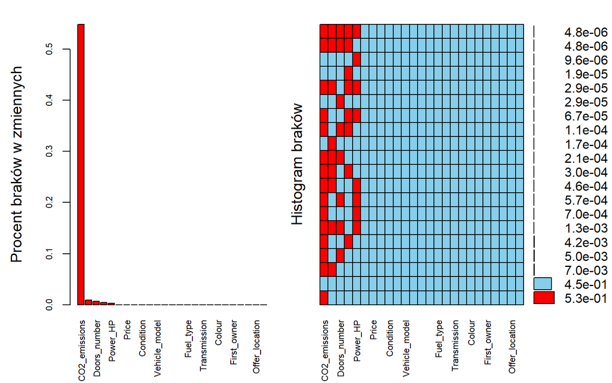

```
##
##  Variables sorted by number of missings:
##                 Variable       Count
##            CO2_emissions 0.548510830
##         Displacement_cm3 0.009438129
##             Doors_number 0.007138605
##               Mileage_km 0.004719064
##                 Power_HP 0.003086835
##                    Index 0.000000000
##                    Price 0.000000000
##                 Currency 0.000000000
##                Condition 0.000000000
##            Vehicle_brand 0.000000000
##            Vehicle_model 0.000000000
##          Vehicle_version 0.000000000
##       Vehicle_generation 0.000000000
##          Production_year 0.000000000
##                Fuel_type 0.000000000
##                    Drive 0.000000000
##             Transmission 0.000000000
##                     Type 0.000000000
##                   Colour 0.000000000
##           Origin_country 0.000000000
##              First_owner 0.000000000
##  First_registration_date 0.000000000
##   Offer_publication_date 0.000000000
##           Offer_location 0.000000000
##                 Features 0.000000000
```

```r
VIM::aggr(dane, numbers = TRUE, sortVars = TRUE,
          labels = names(dane), cex.axis = .7, gap = 3,
          ylab = c("Procent braków w zmiennych", "Histogram braków"))
```

```r
# Usunięcie zmiennych z dużą ilością braków
dane <- dane %>%
  select(-c(CO2_emissions))
```

Sprawdzenie braków po usunięciu zmiennych

```r
library(VIM)
library( naniar )
# Procent braków w każdej zmiennej
procent <- prop_complete_var(dane)
procent
```

```
## [1] 0.8333333
```

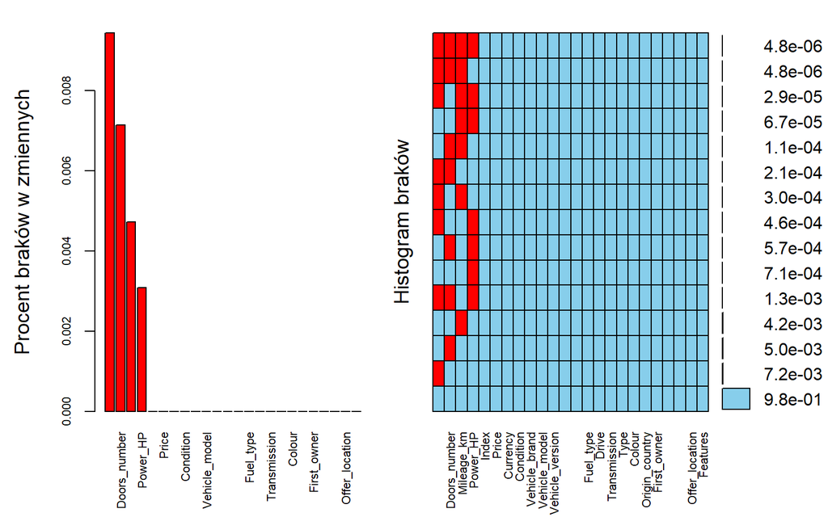

```
##
##  Variables sorted by number of missings:
##                 Variable       Count
##         Displacement_cm3 0.009438129
##             Doors_number 0.007138605
##               Mileage_km 0.004719064
##                 Power_HP 0.003086835
##                    Index 0.000000000
##                    Price 0.000000000
##                 Currency 0.000000000
##                Condition 0.000000000
##            Vehicle_brand 0.000000000
##            Vehicle_model 0.000000000
##          Vehicle_version 0.000000000
##       Vehicle_generation 0.000000000
##          Production_year 0.000000000
##                Fuel_type 0.000000000
##                    Drive 0.000000000
##             Transmission 0.000000000
##                     Type 0.000000000
##                   Colour 0.000000000
##           Origin_country 0.000000000
##              First_owner 0.000000000
##  First_registration_date 0.000000000
##   Offer_publication_date 0.000000000
##           Offer_location 0.000000000
##                 Features 0.000000000
```

```r
VIM::aggr(dane, numbers = TRUE, sortVars = TRUE,
          labels = names(dane), cex.axis = .7, gap = 3,
          ylab = c("Procent braków w zmiennych", "Histogram braków"))
```

korelacja między zmiennymi

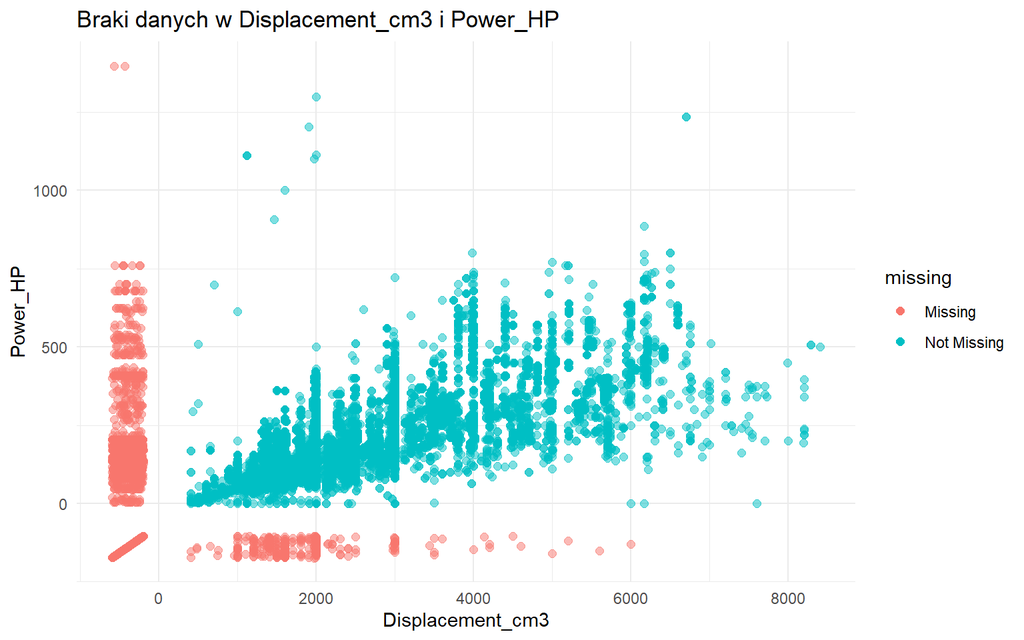

```r
library(ggplot2)
ggplot(data = dane) +
  geom_miss_point(aes(x = Displacement_cm3, y = Power_HP), size = 2, alpha = 0.5) +
  labs(title = "Braki danych w Displacement_cm3 i Power_HP",
       x = "Displacement_cm3",
       y = "Power_HP") +
  theme_minimal()
```

Wypełnienie braków w zmiennych numerycznych (proponuje model liniowy między tymi zmiennymi )

```r
library(mice)
# Wybór zmiennych do imputacji
dane_impute <- dane %>%
  select(Power_HP, Displacement_cm3)
# Imputacja braków za pomocą metody MICE
imputed_data <- mice(dane_impute, m = 5, method = 'pmm', maxit = 5, seed = 123)
# Uzupełnienie oryginalnych danych
dane$Power_HP <- complete(imputed_data)$Power_HP
dane$Displacement_cm3 <- complete(imputed_data)$Displacement_cm3
```

Sprawdzenie braków po imputacji

```r
library(VIM)
library( naniar )
# Procent braków w każdej zmiennej
procent <- prop_complete_var(dane)
procent
```

```
## [1] 0.9166667
```

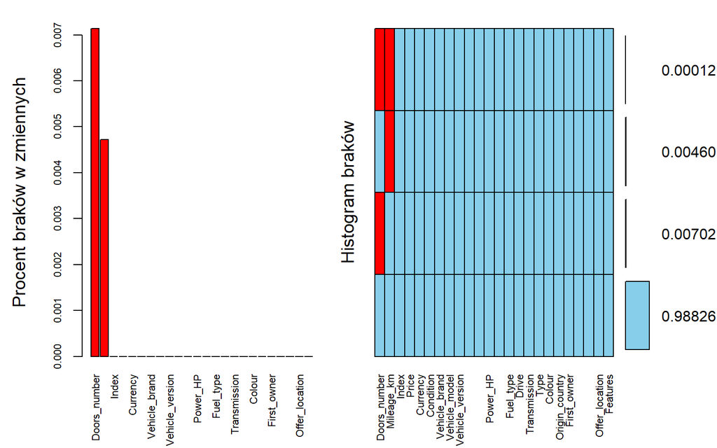

```
##
##  Variables sorted by number of missings:
##                 Variable       Count
##             Doors_number 0.007138605
##               Mileage_km 0.004719064
##                    Index 0.000000000
##                    Price 0.000000000
##                 Currency 0.000000000
##                Condition 0.000000000
##            Vehicle_brand 0.000000000
##            Vehicle_model 0.000000000
##          Vehicle_version 0.000000000
##       Vehicle_generation 0.000000000
##          Production_year 0.000000000
##                 Power_HP 0.000000000
##         Displacement_cm3 0.000000000
##                Fuel_type 0.000000000
##                    Drive 0.000000000
##             Transmission 0.000000000
##                     Type 0.000000000
##                   Colour 0.000000000
##           Origin_country 0.000000000
##              First_owner 0.000000000
##  First_registration_date 0.000000000
##   Offer_publication_date 0.000000000
##           Offer_location 0.000000000
##                 Features 0.000000000
```

```r
VIM::aggr(dane, numbers = TRUE, sortVars = TRUE,
          labels = names(dane), cex.axis = .7, gap = 3,
          ylab = c("Procent braków w zmiennych", "Histogram braków"))
```

zobaczenie korelacji między zmiennymi po imputacji

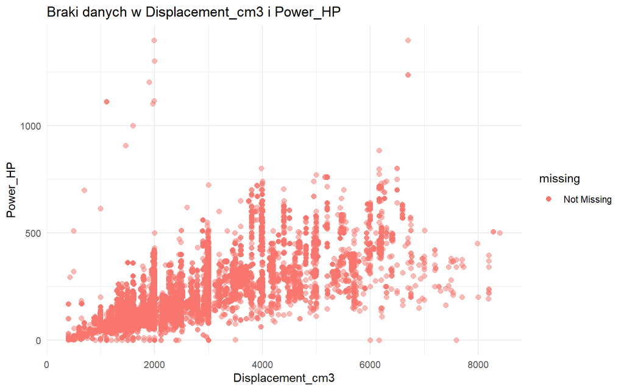

```r
library(ggplot2)
ggplot(data = dane) +
  geom_miss_point(aes(x = Displacement_cm3, y = Power_HP), size = 2, alpha = 0.5) +
  labs(title = "Braki danych w Displacement_cm3 i Power_HP",
       x = "Displacement_cm3",
       y = "Power_HP") +
  theme_minimal()
```

użycie mice dla zmiennnej `Mileage_km`

```r
library(mice)
# Wybór zmiennych do imputacji
dane_impute <- dane %>%
  select(Mileage_km,Production_year,Power_HP)
# Imputacja braków za pomocą metody MICE
imputed_data <- mice(dane_impute, m = 5, method = 'pmm', maxit = 5, seed = 123)
# Uzupełnienie oryginalnych danych
dane$Mileage_km <- complete(imputed_data)$Mileage_km
```

uzupełnienie liczby drzwi za pomocą mice

```r
library(mice)
dane_impute <- dane %>%
  select(Doors_number,Type)
# Imputacja braków za pomocą metody MICE
imputed_data <- mice(dane_impute, m = 5, method = 'pmm', maxit = 5, seed = 123)
# Uzupełnienie oryg inalnych danych
dane$Doors_number <- complete(imputed_data)$Doors_number
```

Sprawdzenie braków po imputacji

```r
library(VIM)
library( naniar )
# Procent braków w każdej zmiennej
procent <- prop_complete_var(dane)
procent
```

```
## [1] 1
```

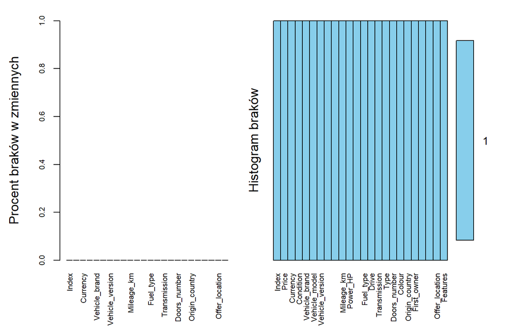

```
##
##  Variables sorted by number of missings:
##                 Variable Count
##                    Index     0
##                    Price     0
##                 Currency     0
##                Condition     0
##            Vehicle_brand     0
##            Vehicle_model     0
##          Vehicle_version     0
##       Vehicle_generation     0
##          Production_year     0
##               Mileage_km     0
##                 Power_HP     0
##         Displacement_cm3     0
##                Fuel_type     0
##                    Drive     0
##             Transmission     0
##                     Type     0
##             Doors_number     0
##                   Colour     0
##           Origin_country     0
##              First_owner     0
##  First_registration_date     0
##   Offer_publication_date     0
##           Offer_location     0
##                 Features     0
```

```r
VIM::aggr(dane, numbers = TRUE, sortVars = TRUE,
          labels = names(dane), cex.axis = .7, gap = 3,
          ylab = c("Procent braków w zmiennych", "Histogram braków"))
```

Koniec uzupełniania braków danych, można przejść do dalszych kroków

## 2.2. Walidacja danych

Ustalenie reguł walidacji dla zmiennych numerycznych i kategorycznych

`Price` - powinna być większa od 0 `Mileage_km` - musi być liczbą nieujemną i mniejsze od 999999 `Production_year` - musi być liczbą całkowitą mieszczącą się w rozsądnym zakresie (np. od 1886 włącznie). `Power_HP` - musi być liczbą nieujemną. `Displacement_cm3` - musi być liczbą nieujemną. `Doors_number` - musi być liczbą całkowitą z przedziału (1-6)

error locate, walidate - pakiety do wykorzystania

raport4 tam jest zrobione błędy walidacji

Następnie przeprowadzenie walidacji danych zgodnie z ustalonymi regułami

np zamienić na braki lub wyliczyć

```r
library(validate)
rules <- validator(
  Price > 0,
  Production_year >= 1886 & Production_year <= as.numeric(format(Sys.Date(), "%Y")),
  Mileage_km >= 0,
  Mileage_km < 999999,
  Power_HP > 1,
  Displacement_cm3 > 0,
  Doors_number %in% c(1:6)
)
```

```r
cf <- confront(dane, rules)
summary(cf)[,1:4]
```

```
##   name  items passes fails
## 1   V1 208304 208304     0
## 2   V2 208304 208304     0
## 3   V3 208304 208304     0
## 4   V4 208304 208260    44
## 5   V5 208304 208251    53
## 6   V6 208304 208304     0
## 7   V7 208304 208291    13
```

```r
dane$Price[!(dane$Price > 0)] <- NA
dane$Production_year[!(dane$Production_year >= 1886 &
                       dane$Production_year <= as.numeric(format(Sys.Date(), "%Y")))] <- NA
dane$Mileage_km[!(dane$Mileage_km >= 0 & dane$Mileage_km < 999999)] <- NA
dane$Power_HP[!(dane$Power_HP > 1)] <- NA
dane$Displacement_cm3[!(dane$Displacement_cm3 > 0)] <- NA
dane$Doors_number[!(dane$Doors_number %in% 1:6)] <- NA
```

Sprawdzenie braków po walidacji

```r
library(VIM)
library( naniar )
# Procent braków w każdej zmiennej
procent <- prop_complete_var(dane)
procent
```

```
## [1] 0.875
```

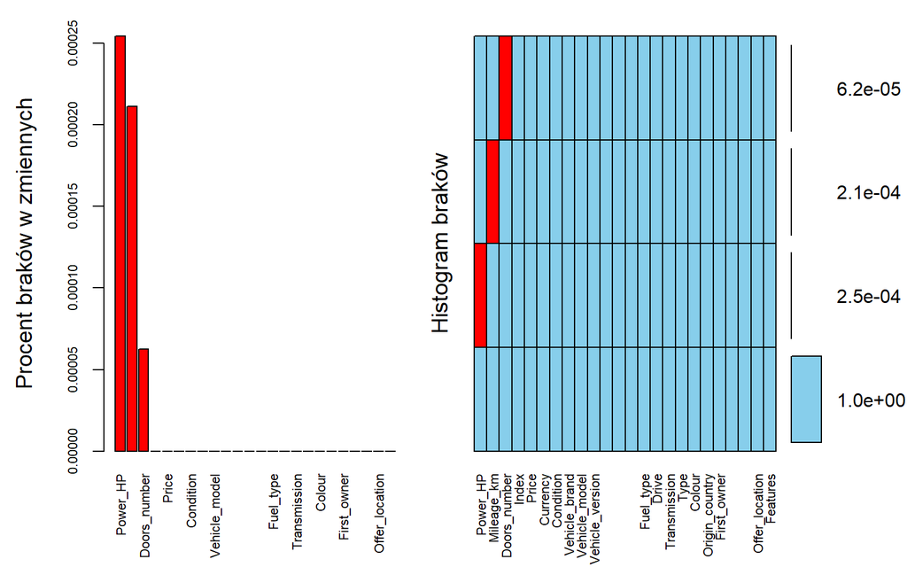

```
##
##  Variables sorted by number of missings:
##                 Variable        Count
##                 Power_HP 2.544358e-04
##               Mileage_km 2.112297e-04
##             Doors_number 6.240879e-05
##                    Index 0.000000e+00
##                    Price 0.000000e+00
##                 Currency 0.000000e+00
##                Condition 0.000000e+00
##            Vehicle_brand 0.000000e+00
##            Vehicle_model 0.000000e+00
##          Vehicle_version 0.000000e+00
##       Vehicle_generation 0.000000e+00
##          Production_year 0.000000e+00
##         Displacement_cm3 0.000000e+00
##                Fuel_type 0.000000e+00
##                    Drive 0.000000e+00
##             Transmission 0.000000e+00
##                     Type 0.000000e+00
##                   Colour 0.000000e+00
##           Origin_country 0.000000e+00
##              First_owner 0.000000e+00
##  First_registration_date 0.000000e+00
##   Offer_publication_date 0.000000e+00
##           Offer_location 0.000000e+00
##                 Features 0.000000e+00
```

```r
VIM::aggr(dane, numbers = TRUE, sortVars = TRUE,
          labels = names(dane), cex.axis = .7, gap = 3,
          ylab = c("Procent braków w zmiennych", "Histogram braków"))
```

Dalsze uzupełnianie braków danych Power_HP po walidacji za pomocą MICE

```r
library(mice)
# Wybór zmiennych do imputacji
dane_impute <- dane %>%
  select(Power_HP, Doors_number, Displacement_cm3, Type)
# Imputacja braków za pomocą metody MICE
imputed_data <- mice(dane_impute, m = 5, method = 'pmm', maxit = 5, seed = 123)
# Uzupełnienie oryginalnych danych
dane$Power_HP <- complete(imputed_data)$Power_HP
```

Uzupełnianie braków w Doors_number po walidacji za pomocą KNN imputation

```r
library(VIM)

dane <- kNN(dane, variable = "Doors_number", k = 5, dist_var = c("Type","Vehicle_model"))
```

uzupełnianie braków w Mileage_km po walidacji za pomocą MICE

```r
library(mice)
# Wybór zmiennych do imputacji
dane_impute <- dane %>%
  select(Mileage_km,Production_year,Power_HP)
# Imputacja braków za pomocą metody MICE
imputed_data <- mice(dane_impute, m = 5, method = 'pmm', maxit = 5, seed = 123)
# Uzupełnienie oryginalnych danych
dane$Mileage_km <- complete(imputed_data)$Mileage_km
```

Sprawdzenie braków po uzupełnianiu po walidacji

```r
library(VIM)
library( naniar )
# Procent braków w każdej zmiennej
procent <- prop_complete_var(dane)
procent
```

```
## [1] 1
```

Spradzenie spełniania reguł walidacji po uzupełnianiu braków

```r
cf <- confront(dane, rules)
summary(cf)
```

```
##   name  items passes fails nNA error warning
## 1   V1 208304 208304     0   0 FALSE   FALSE
## 2   V2 208304 208304     0   0 FALSE   FALSE
## 3   V3 208304 208304     0   0 FALSE   FALSE
## 4   V4 208304 208304     0   0 FALSE   FALSE
## 5   V5 208304 208304     0   0 FALSE   FALSE
## 6   V6 208304 208304     0   0 FALSE   FALSE
## 7   V7 208304 208304     0   0 FALSE   FALSE
##                                                                                   expression
## 1                                                                                  Price > 0
## 2 Production_year - 1886 >= -1e-08 & Production_year <= as.numeric(format(Sys.Date(), "%Y"))
## 3                                                                   Mileage_km - 0 >= -1e-08
## 4                                                                        Mileage_km < 999999
## 5                                                                               Power_HP > 1
## 6                                                                       Displacement_cm3 > 0
## 7                                                                  Doors_number %vin% c(1:6)
```

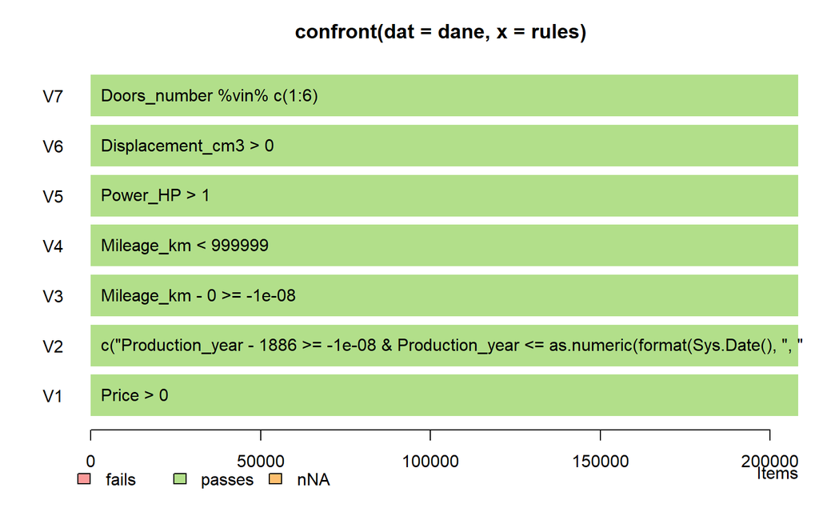

```r
barplot(cf)
```

Ostatecznie mamy dane, które spełniają kryteria walidacji i nie zawierają braków danych. Możemy przejść do dalszej analizy danych. Dla uzyskanych danych wybieramy marki Mercedes i BMW do dalszej analizy i zapisujemy plik zawierający te dane.

```r
dane <- dane %>%
  filter(
    Vehicle_brand %in% c("BMW", "Mercedes-Benz"),
    Currency == "PLN",
    Condition == "Used"
  )

write.csv(dane, "dane/Car_sale_ads_cleaned.csv", row.names = FALSE)
```

# 3. Wizualizacja danych w celu weryfikacji hipotez

```r
# Paleta kolorów marek (do wielokrotnego użycia w całym projekcie)
brand_colors <- c(
  "BMW" = "#1f77b4",        # niebieski premium
  "Mercedes" = "#7f7f7f"   # elegancka szarość
)
```

```r
library(dplyr)
library(tidyr)
library(knitr)
library(kableExtra)
library(scales)

# Filtrujemy tylko auta używane i wybrane marki
daneused <- dane %>%
  filter(Condition == "Used", Vehicle_brand %in% c("BMW", "Mercedes-Benz"))

# Lista zmiennych numerycznych, które istnieją w danych
num_vars <- c("Price", "Mileagekm", "Productionyear", "PowerHP", "Displacementcm3")
num_vars_exist <- intersect(num_vars, names(daneused))

# Tworzymy tabelę opisową
tabela_opisowa <- daneused %>%
  group_by(Vehicle_brand) %>%
  summarise(
    n = n(),
    across(all_of(num_vars_exist),
           list(
             mean = ~mean(.x, na.rm = TRUE),
             sd   = ~sd(.x, na.rm = TRUE),
             min  = ~min(.x, na.rm = TRUE),
             q1   = ~quantile(.x, 0.25, na.rm = TRUE),
             med  = ~median(.x, na.rm = TRUE),
             q3   = ~quantile(.x, 0.75, na.rm = TRUE),
             max  = ~max(.x, na.rm = TRUE)
           ),
           .names = "{.col}_{.fn}"
    ),
    .groups = "drop"
  ) %>%
  pivot_longer(
    -c(Vehicle_brand, n),
    names_to = c("Zmienna", "Stat"),
    names_sep = "_",
    values_to = "Wartosc"
  ) %>%
  pivot_wider(names_from = Stat, values_from = Wartosc) %>%
  # Usuwamy kolumnę Zmienna
  select(-Zmienna) %>%
  relocate(Vehicle_brand, n, mean, sd, min, q1, med, q3, max) %>%
  mutate(
    across(c(mean, sd, min, q1, med, q3, max), ~round(.x, 0)),
    across(c(mean, sd, min, q1, med, q3, max), ~comma(.x, big.mark = " "))
  )

# Tworzymy tabelę HTML z wyśrodkowanymi kolumnami
tabela_opisowa %>%
  arrange(Vehicle_brand) %>%
  kable(
    "html",
    caption = "Statystyki opisowe dla cen w PLN – BMW vs Mercedes-Benz",
    col.names = c("Marka", "Liczba ogłoszeń", "Średnia", "SD", "Min", "Q1", "Mediana", "Q3", "Max"),
    align = "c"  # wyśrodkowanie wszystkich kolumn
  ) %>%
  kable_styling(
    full_width = FALSE,
    bootstrap_options = c("striped", "condensed", "hover")
  ) %>%
  row_spec(0, bold = TRUE, color = "white", background = "#2C3E50")  # nagłówek
```

Statystyki opisowe dla cen w PLN – BMW vs Mercedes-Benz

| Marka | Liczba ogłoszeń | Średnia | SD | Min | Q1 | Mediana | Q3 | Max |
| --- | --- | --- | --- | --- | --- | --- | --- | --- |
| BMW | 15150 | 78 568 | 100 574 | 1 300 | 24 500 | 51 900 | 99 000 | 6 999 000 |
| Mercedes-Benz | 10928 | 91 710 | 111 847 | 1 000 | 22 500 | 52 500 | 120 824 | 1 398 999 |

# 3.1. Weryfikacja hipotez

Hipoteza H1 (Cena a przebieg) - tylko dla używanych samochodów, dla Mercedesa i BMW

```r
library(dplyr)
library(rlang)
```

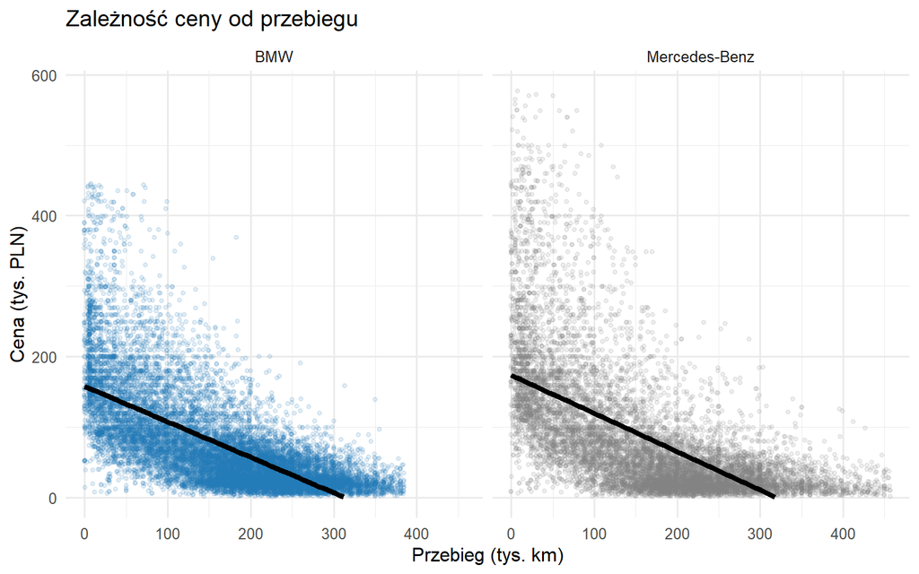

```r
library(ggplot2)

dane_used <- dane %>%
  filter(Condition == "Used") %>%
  group_by(Vehicle_brand) %>%
  filter(
    Mileage_km <= quantile(Mileage_km, 0.99, na.rm = TRUE),
    Price <= quantile(Price, 0.99, na.rm = TRUE)
  ) %>%
  ungroup()

ggplot(
  dane_used,
  aes(x = Mileage_km, y = Price)
) +
  geom_point(
    aes(color = Vehicle_brand),
    alpha = 0.12,
    size = 1
  ) +
  geom_smooth(
    method = "lm",
    se = FALSE,
    color = "black",     # 🔹 KONTRASTOWA LINIA
    linewidth = 1.6
  ) +
  facet_wrap(~ Vehicle_brand) +
  scale_color_manual(values = brand_colors) +
  scale_x_continuous(
    labels = function(x) x / 1000,
    name = "Przebieg (tys. km)"
  ) +
  scale_y_continuous(
    limits = c(0, NA),
    labels = function(x) x / 1000,
    name = "Cena (tys. PLN)"
  ) +
  labs(
    title = "Zależność ceny od przebiegu",
  ) +
  theme_minimal(base_size = 12) +
  theme(legend.position = "none")
```

```r
library(dplyr)
library(tidyr)
library(knitr)
library(kableExtra)
library(scales)

# 1) Filtracja danych
dane_used <- dane %>%
  filter(
    Condition == "Used",
    Vehicle_brand %in% c("BMW", "Mercedes-Benz")
  ) %>%
  group_by(Vehicle_brand) %>%
  filter(
    Mileage_km <= quantile(Mileage_km, 0.99, na.rm = TRUE),
    Price      <= quantile(Price,      0.99, na.rm = TRUE)
  ) %>%
  ungroup()

# 2) Korelacja cena–przebieg per marka
corr_tab <- dane_used %>%
  group_by(Vehicle_brand) %>%
  summarise(
    r_cena_przebieg = cor(Mileage_km, Price, use = "complete.obs", method = "pearson"),
    .groups = "drop"
  )

# 3) Statystyki opisowe dla Mileage_km
tab_long <- dane_used %>%
  select(Vehicle_brand, Mileage_km) %>%
  pivot_longer(
    cols = Mileage_km,
    names_to = "Zmienna",
    values_to = "Wartosc"
  ) %>%
  group_by(Vehicle_brand) %>%
  summarise(
    n = sum(!is.na(Wartosc)),
    Srednia = mean(Wartosc, na.rm = TRUE),
    SD = sd(Wartosc, na.rm = TRUE),
    Min = min(Wartosc, na.rm = TRUE),
    Q1 = quantile(Wartosc, 0.25, na.rm = TRUE),
    Mediana = median(Wartosc, na.rm = TRUE),
    Q3 = quantile(Wartosc, 0.75, na.rm = TRUE),
    Max = max(Wartosc, na.rm = TRUE),
    .groups = "drop"
  )

# 4) Sklejenie: marka + r + statystyki przebiegu
tab_final <- tab_long %>%
  left_join(corr_tab, by = "Vehicle_brand") %>%
  select(
    Marka = Vehicle_brand,
    r_cena_przebieg,
    n,
    Srednia, SD, Min, Q1, Mediana, Q3, Max
  ) %>%
  mutate(
    across(-c(Marka, r_cena_przebieg), ~comma(round(.x, 0), big.mark = " ")),
    r_cena_przebieg = round(r_cena_przebieg, 2)
  )

# 5) Render tabeli w tym samym stylu
tab_final %>%
  kable(
    "html",
    caption = "Statystyki opisowe przebiegu w KM oraz wartość korelacji z ceną: BMW vs Mercedes-Benz",
    align = "c",
    col.names = c("Marka", "Wsp korelacji", "Liczba", "Średnia", "SD", "Min", "Q1", "Mediana", "Q3", "Max")
  ) %>%
  kable_styling(
    full_width = FALSE,
    bootstrap_options = c("striped", "condensed", "hover")
  ) %>%
  row_spec(0, bold = TRUE, color = "white", background = "#2C3E50")
```

Statystyki opisowe przebiegu w KM oraz wartość korelacji z ceną: BMW vs Mercedes-Benz

| Marka | Wsp korelacji | Liczba | Średnia | SD | Min | Q1 | Mediana | Q3 | Max |
| --- | --- | --- | --- | --- | --- | --- | --- | --- | --- |
| BMW | -0.67 | 14 850 | 167 091 | 92 145 | 1 | 90 518 | 176 000 | 237 000 | 385 000 |
| Mercedes-Benz | -0.61 | 10 708 | 162 665 | 102 020 | 1 | 76 000 | 162 258 | 235 632 | 456 789 |

Wyniki dla aut używanych (po odcięciu górnego 1% wartości Price i Mileage_km w obrębie każdej marki) wspierają hipotezę H1: wraz ze wzrostem przebiegu cena spada, co widać po wyraźnie opadającej linii trendu w obu panelach (BMW i Mercedes-Benz). Zależność tę potwierdza także współczynnik korelacji Pearsona między przebiegiem a ceną, który jest ujemny dla obu marek (BMW: r ≈ −0.67, Mercedes-Benz: r ≈ −0.61), co oznacza, że większy przebieg wiąże się przeciętnie z niższą ceną (nieco silniej w BMW).

Z tabeli wynika, że „typowe” ceny są bardzo zbliżone (mediany ok. 52 tys. PLN dla obu marek), ale Mercedes ma wyżej położoną górną część rozkładu cen (Q3 wyższe niż w BMW), co widać też w większej liczbie droższych punktów przy mniejszych przebiegach.

Na wykresie widać również skośność cen: większość obserwacji skupia się przy niższych poziomach cen, a jednocześnie występuje „ogon” droższych ofert (zwłaszcza przy niskich przebiegach), co jest typowym obrazem prawostronnie skośnego rozkładu cen i tłumaczy, dlaczego średnia bywa wyższa od mediany.

Hipoteza H2 (Cena a rok produkcji) - tylko dla używanych samochodów, weług marek (moze dodac tu ymax? i pokombinowac z rokiem zeby bylo czytelniej?)

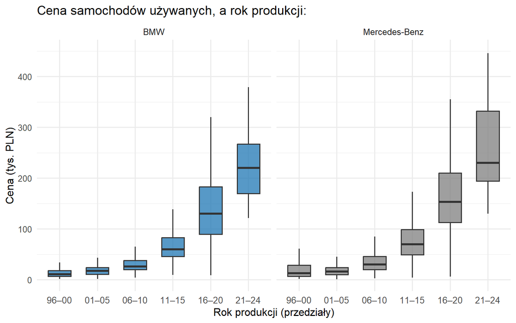

```r
dane_used <- dane %>%
  filter(Condition == "Used") %>%
  mutate(
    Year_group = cut(
      Production_year,
      breaks = c(1995, 2000, 2005, 2010, 2015, 2020, 2025),
      labels = c(
        "96–00",
        "01–05",
        "06–10",
        "11–15",
        "16–20",
        "21–24"
      )
    )
  ) %>%
  filter(!is.na(Year_group))
ggplot(
  dane_used,
  aes(x = Year_group, y = Price, fill = Vehicle_brand)
) +
  geom_boxplot(
    outlier.shape = NA,
    alpha = 0.75,
    width = 0.6
  ) +
  facet_wrap(~ Vehicle_brand) +
  scale_fill_manual(values = brand_colors) +
  scale_y_continuous(
    limits = c(0, 450000),
    labels = function(x) x / 1000,
    name = "Cena (tys. PLN)"
  ) +
  labs(
    title = "Cena samochodów używanych, a rok produkcji:",
    x = "Rok produkcji (przedziały)",
    fill = "Marka"
  ) +
  theme_minimal(base_size = 12) +
  theme(
    axis.text.x = element_text(size = 10),
    legend.position = "none"
  )
```

```r
library(dplyr)
library(knitr)
library(kableExtra)
library(scales)

# Przygotowanie danych z grupami lat
dane_used <- dane %>%
  filter(Condition == "Used") %>%
  mutate(
    Year_group = cut(
      Production_year,
      breaks = c(1995, 2000, 2005, 2010, 2015, 2020, 2025),
      labels = c(
        "96–00",
        "01–05",
        "06–10",
        "11–15",
        "16–20",
        "21–24"
      ),
      right = FALSE
    )
  ) %>%
  filter(!is.na(Year_group))

# Tabela H2 z dodaną średnią arytmetyczną
tab_h2 <- dane_used %>%
  filter(Price <= 450000) %>%
  filter(Vehicle_brand %in% c("BMW", "Mercedes-Benz")) %>%
  group_by(Vehicle_brand, Year_group) %>%
  summarise(
    n = sum(!is.na(Price)),
    Srednia = mean(Price, na.rm = TRUE),
    Q1 = quantile(Price, 0.25, na.rm = TRUE),
    Mediana = median(Price, na.rm = TRUE),
    Q3 = quantile(Price, 0.75, na.rm = TRUE),
    .groups = "drop"
  ) %>%
  arrange(Vehicle_brand, Year_group) %>%
  mutate(across(c(n, Srednia, Q1, Mediana, Q3), ~comma(round(.x, 0), big.mark = " ")))

# Render tabeli
tab_h2 %>%
  kable(
    "html",
    caption = "H2: Cena samochodów W PLN według roku produkcji",
    align = "c",
    col.names = c("Marka", "Rok grupy", "Liczba", "Średnia", "Q1", "Mediana", "Q3")
  ) %>%
  kable_styling(
    full_width = FALSE,
    bootstrap_options = c("striped", "condensed", "hover")
  ) %>%
  row_spec(0, bold = TRUE, color = "white", background = "#2C3E50")
```

H2: Cena samochodów W PLN według roku produkcji

| Marka | Rok grupy | Liczba | Średnia | Q1 | Mediana | Q3 |
| --- | --- | --- | --- | --- | --- | --- |
| BMW | 96–00 | 393 | 16 253 | 6 990 | 11 500 | 20 000 |
| BMW | 01–05 | 1 433 | 17 680 | 8 900 | 13 900 | 22 500 |
| BMW | 06–10 | 3 825 | 28 043 | 18 500 | 23 800 | 30 900 |
| BMW | 11–15 | 4 120 | 60 804 | 39 969 | 53 900 | 71 999 |
| BMW | 16–20 | 4 391 | 128 356 | 79 900 | 109 900 | 163 590 |
| BMW | 21–24 | 670 | 216 332 | 159 900 | 199 900 | 259 900 |
| Mercedes-Benz | 96–00 | 380 | 29 587 | 7 952 | 16 000 | 42 600 |
| Mercedes-Benz | 01–05 | 1 347 | 21 395 | 8 900 | 14 900 | 22 200 |
| Mercedes-Benz | 06–10 | 2 597 | 34 157 | 16 900 | 26 900 | 39 900 |
| Mercedes-Benz | 11–15 | 2 236 | 71 883 | 42 000 | 57 350 | 84 900 |
| Mercedes-Benz | 16–20 | 2 839 | 153 661 | 93 900 | 135 000 | 186 050 |
| Mercedes-Benz | 21–24 | 516 | 226 295 | 160 490 | 199 900 | 279 900 |

Dla aut używanych (BMW i Mercedes-Benz) porównano ceny w przedziałach rocznika produkcji, a do analizy przyjęto ten sam zakres co na wykresie (ceny ograniczone do 450000 PLN).

Hipoteza H3 (Typ nadwozia a cena) - tylko dla używanych samochodów, weług marek Weryfikacja: porównanie rozkładów `Price`między kategoriami zmiennej `Type` (boxploty, testy różnic średnich / ANOVA).

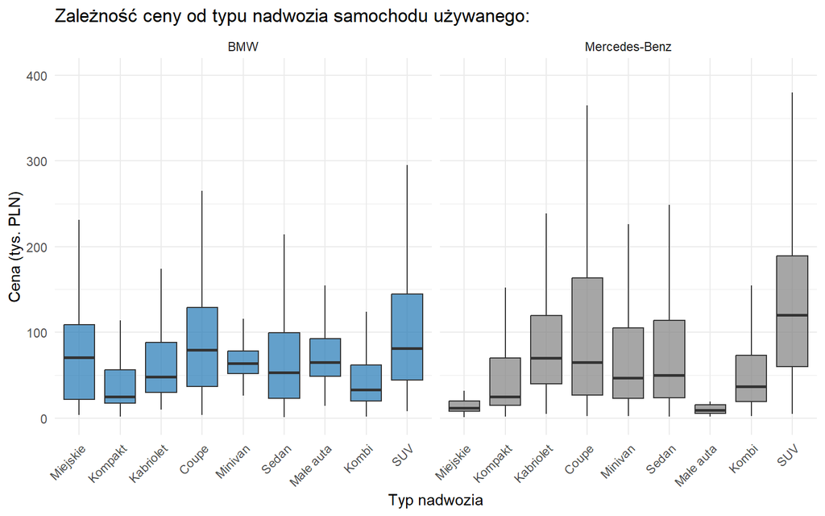

```r
library(ggplot2)

# Paleta kolorów marek
brand_colors <- c(
  "BMW" = "#1f77b4",
  "Mercedes" = "#7f7f7f"
)

dane_used <- dane %>% filter(Condition == "Used")

ggplot(dane_used, aes(x = Type, y = Price, fill = Vehicle_brand)) +
  geom_boxplot(outlier.shape = NA, alpha = 0.7) +
  facet_grid(~ Vehicle_brand, scales = "fixed") +
  coord_cartesian(ylim = c(0, 400000)) +
  labs(
    title = "Zależność ceny od typu nadwozia samochodu używanego:",
    x = "Typ nadwozia",
    y = "Cena (tys. PLN)"
  ) +
  scale_y_continuous(labels = function(x) x / 1000) +
  scale_x_discrete(labels = c(
    "city_cars"     = "Miejskie",
    "compact"       = "Kompakt",
    "convertible"   = "Kabriolet",
    "coupe"         = "Coupe",
    "minivan"       = "Minivan",
    "sedan"         = "Sedan",
    "small_cars"    = "Małe auta",
    "station_wagon" = "Kombi",
    "SUV"           = "SUV"
  )) +
  scale_fill_manual(values = brand_colors) +
  theme_minimal() +
  theme(
    axis.text.x = element_text(angle = 45, hjust = 1),
    legend.position = "none"
  )
```

```r
library(dplyr)
library(knitr)
library(kableExtra)
library(scales)

# Tabela H3: Cena vs typ nadwozia z dodaną średnią
tab_h3 <- dane %>%
  filter(
    Condition == "Used",
    Vehicle_brand %in% c("BMW", "Mercedes-Benz"),
    !is.na(Price),
    Price <= 400000
  ) %>%
  group_by(Vehicle_brand, Type) %>%
  summarise(
    n = sum(!is.na(Price)),
    Srednia = mean(Price, na.rm = TRUE),
    Q1 = quantile(Price, 0.25, na.rm = TRUE),
    Mediana = median(Price, na.rm = TRUE),
    Q3 = quantile(Price, 0.75, na.rm = TRUE),
    .groups = "drop"
  ) %>%
  arrange(Vehicle_brand, desc(Mediana)) %>%
  mutate(across(c(n, Srednia, Q1, Mediana, Q3), ~comma(round(.x, 0), big.mark = " ")))

# Render tabeli w tym samym stylu
tab_h3 %>%
  kable(
    "html",
    caption = "H3: Cena w PLN według typów nadwozia BMW vs Mercedes-Benz",
    align = "c",
    col.names = c("Marka", "Typ nadwozia", "Liczba", "Średnia", "Q1", "Mediana", "Q3")
  ) %>%
  kable_styling(
    full_width = FALSE,
    bootstrap_options = c("striped", "condensed", "hover")
  ) %>%
  row_spec(0, bold = TRUE, color = "white", background = "#2C3E50")
```

H3: Cena w PLN według typów nadwozia BMW vs Mercedes-Benz

| Marka | Typ nadwozia | Liczba | Średnia | Q1 | Mediana | Q3 |
| --- | --- | --- | --- | --- | --- | --- |
| BMW | SUV | 3 090 | 101 069 | 43 900 | 79 900 | 139 900 |
| BMW | coupe | 1 106 | 91 677 | 35 900 | 76 950 | 121 500 |
| BMW | city_cars | 292 | 76 192 | 21 498 | 70 450 | 109 118 |
| BMW | small_cars | 34 | 70 598 | 48 500 | 64 900 | 92 625 |
| BMW | minivan | 182 | 67 805 | 51 925 | 63 572 | 77 975 |
| BMW | sedan | 5 370 | 73 048 | 22 900 | 51 000 | 94 900 |
| BMW | convertible | 326 | 66 046 | 29 900 | 47 200 | 84 975 |
| BMW | station_wagon | 2 969 | 49 656 | 19 900 | 32 900 | 61 700 |
| BMW | compact | 1 584 | 44 467 | 17 000 | 24 900 | 55 900 |
| Mercedes-Benz | SUV | 1 545 | 131 325 | 59 000 | 116 000 | 179 900 |
| Mercedes-Benz | convertible | 524 | 91 020 | 39 900 | 66 500 | 100 000 |
| Mercedes-Benz | coupe | 1 190 | 94 181 | 25 475 | 58 850 | 133 884 |
| Mercedes-Benz | sedan | 3 724 | 77 167 | 22 900 | 48 542 | 106 000 |
| Mercedes-Benz | minivan | 692 | 75 288 | 22 900 | 46 900 | 102 356 |
| Mercedes-Benz | station_wagon | 1 493 | 56 910 | 18 900 | 36 600 | 73 000 |
| Mercedes-Benz | compact | 1 113 | 51 351 | 14 700 | 24 999 | 70 110 |
| Mercedes-Benz | city_cars | 352 | 21 356 | 7 875 | 11 900 | 19 925 |
| Mercedes-Benz | small_cars | 38 | 19 900 | 5 118 | 9 450 | 15 675 |

Warto też zauważyć, że rozrzut cen (Q1–Q3) dla SUV jest szeroki, co widać na wysokości pudełek na wykresie i sugeruje duże zróżnicowanie ofert w tym typie (różne roczniki, wersje i wyposażenie).

Hipoteza H4 (Skrzynia biegów a cena) - tylko dla używanych samochodów Weryfikacja: porównanie cen `Price` w dwóch grupach (`Transmission` = automat vs manual) z użyciem odpowiednich testów statystycznych i wizualizacji - proponowane wykorzystanie t-test lub Wilcoxon `Price` ~ `Transmission` w podzbiorach marek, wizualizacja violin plots.

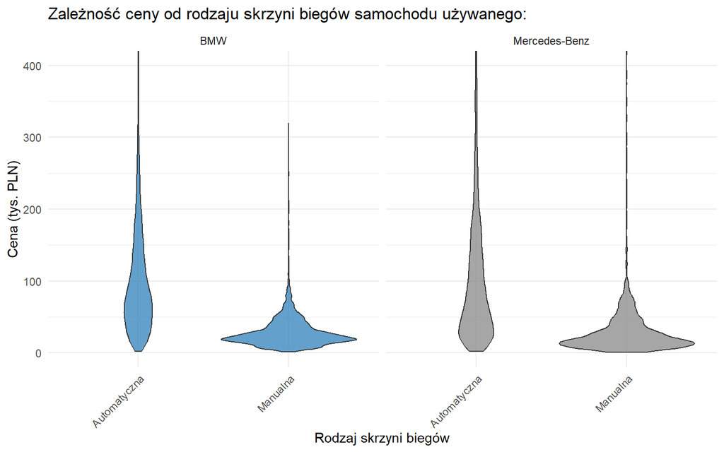

```r
library(ggplot2)
library(dplyr)

# Filtrujemy tylko samochody używane
dane_used <- dane %>% filter(Condition == "Used" & !(Transmission == ""))

ggplot(dane_used, aes(x = Transmission, y = Price, fill = Vehicle_brand)) +
  geom_violin(alpha = 0.7) +
  facet_grid(~ Vehicle_brand, scales = "fixed") +
  coord_cartesian(ylim = c(0, 400000)) +
  labs(
    title = "Zależność ceny od rodzaju skrzyni biegów samochodu używanego:",
    x = "Rodzaj skrzyni biegów",
    y = "Cena (tys. PLN)"
  ) +
  scale_y_continuous(
    labels = function(x) x / 1000
  ) +
  scale_x_discrete(labels = c(
    "Automatic" = "Automatyczna",
    "Manual"    = "Manualna"
  )) +
  scale_fill_manual(values = brand_colors) +  # używamy Twojej palety
  theme_minimal() +
  theme(
    axis.text.x = element_text(angle = 45, hjust = 1),
    legend.position = "none"  # ukrywamy legendę
  )
```

```r
library(dplyr)
library(knitr)
library(kableExtra)
library(scales)

# Tabela H4 w układzie długim
tab_h4_long <- dane %>%
  filter(
    Condition == "Used",
    Vehicle_brand %in% c("BMW", "Mercedes-Benz"),
    Transmission %in% c("Automatic", "Manual"),
    !is.na(Price),
    Price <= 400000
  ) %>%
  group_by(Vehicle_brand, Transmission) %>%
  summarise(
    n = sum(!is.na(Price)),
    Srednia = mean(Price, na.rm = TRUE),
    Q1 = quantile(Price, 0.25, na.rm = TRUE),
    Mediana = median(Price, na.rm = TRUE),
    Q3 = quantile(Price, 0.75, na.rm = TRUE),
    .groups = "drop"
  ) %>%
  rename(Marka = Vehicle_brand, Skrzynia = Transmission) %>%
  arrange(Marka, Skrzynia) %>%
  mutate(across(c(n, Srednia, Q1, Mediana, Q3), ~comma(round(.x, 0), big.mark = " ")))

# Render w stylu raportowym
tab_h4_long %>%
  kable(
    "html",
    caption = "H4: Cena a skrzynia biegów (używane, Price ≤ 400 000)",
    align = "c",
    col.names = c("Marka", "Skrzynia biegów", "Liczba", "Średnia", "Q1", "Mediana", "Q3")
  ) %>%
  kable_styling(
    full_width = FALSE,
    bootstrap_options = c("striped", "condensed", "hover")
  ) %>%
  row_spec(0, bold = TRUE, color = "white", background = "#2C3E50")
```

H4: Cena a skrzynia biegów (używane, Price ≤ 400 000)

| Marka | Skrzynia biegów | Liczba | Średnia | Q1 | Mediana | Q3 |
| --- | --- | --- | --- | --- | --- | --- |
| BMW | Automatic | 9 455 | 97 287 | 46 900 | 78 900 | 131 900 |
| BMW | Manual | 5 435 | 29 276 | 16 500 | 23 400 | 36 900 |
| Mercedes-Benz | Automatic | 7 753 | 98 214 | 34 900 | 73 900 | 139 900 |
| Mercedes-Benz | Manual | 2 884 | 30 667 | 11 900 | 19 900 | 38 500 |

Hipoteza H5 (Pierwszy właściciel a cena) - tylko dla używanych samochodów Weryfikacja: porównanie `Price` dla zmiennej `First_owner` (tak vs nie) z wykorzystaniem wykresów oraz testów różnic średnich.

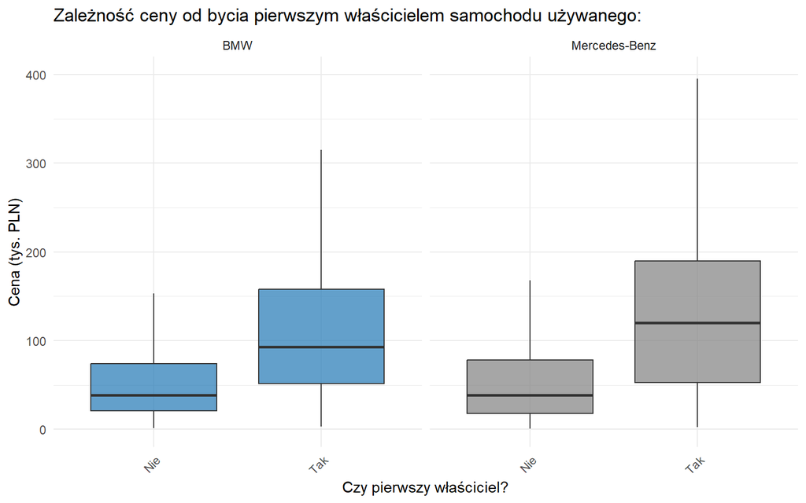

```r
library(ggplot2)
library(dplyr)

dane_used <- dane %>%
  filter(Condition == "Used") %>%
  mutate(
    First_owner_lab = ifelse(First_owner == "Yes", "Tak", "Nie")
  )

ggplot(dane_used, aes(x = First_owner_lab, y = Price, fill = Vehicle_brand)) +
  geom_boxplot(outlier.shape = NA, alpha = 0.7) +
  facet_grid(~ Vehicle_brand, scales = "fixed") +
  coord_cartesian(ylim = c(0, 400000)) +
  labs(
    title = "Zależność ceny od bycia pierwszym właścicielem samochodu używanego:",
    x = "Czy pierwszy właściciel?",
    y = "Cena (tys. PLN)",
    fill = "Marka Samochodu"
  ) +
  scale_y_continuous(
    labels = function(x) x / 1000
  ) +
  scale_fill_manual(values = brand_colors) +  # używamy Twojej palety kolorów
  theme_minimal() +
  theme(
    axis.text.x = element_text(angle = 45, hjust = 1),
    legend.position = "none"  # legendę możemy ukryć, bo mamy facet_grid
  )
```

```r
library(dplyr)
library(knitr)
library(kableExtra)
library(scales)

# Przygotowanie danych do tabeli H5
tab_h5 <- dane %>%
  filter(
    Condition == "Used",
    Vehicle_brand %in% c("BMW", "Mercedes-Benz"),
    !is.na(Price),
    Price <= 400000
  ) %>%
  mutate(
    Pierwszy_wlasciciel = ifelse(First_owner == "Yes", "Tak", "Nie")
  ) %>%
  group_by(Vehicle_brand, Pierwszy_wlasciciel) %>%
  summarise(
    n = sum(!is.na(Price)),
    Srednia = mean(Price, na.rm = TRUE),
    Q1 = quantile(Price, 0.25, na.rm = TRUE),
    Mediana = median(Price, na.rm = TRUE),
    Q3 = quantile(Price, 0.75, na.rm = TRUE),
    .groups = "drop"
  ) %>%
  rename(Marka = Vehicle_brand, `Pierwszy właściciel` = Pierwszy_wlasciciel) %>%
  arrange(Marka, `Pierwszy właściciel`) %>%
  mutate(across(c(n, Srednia, Q1, Mediana, Q3), ~comma(round(.x, 0), big.mark = " ")))

# Render tabeli w stylu raportowym
tab_h5 %>%
  kable(
    "html",
    caption = "H5: Cena samochodu w zależności od bycia pierwszym właścicielem (używane, Price ≤ 400 000)",
    align = "c",
    col.names = c("Marka", "Pierwszy właściciel", "Liczba", "Średnia", "Q1", "Mediana", "Q3")
  ) %>%
  kable_styling(
    full_width = FALSE,
    bootstrap_options = c("striped", "condensed", "hover")
  ) %>%
  row_spec(0, bold = TRUE, color = "white", background = "#2C3E50")
```

H5: Cena samochodu w zależności od bycia pierwszym właścicielem (używane, Price ≤ 400 000)

| Marka | Pierwszy właściciel | Liczba | Średnia | Q1 | Mediana | Q3 |
| --- | --- | --- | --- | --- | --- | --- |
| BMW | Nie | 10 515 | 57 557 | 20 900 | 38 900 | 72 900 |
| BMW | Tak | 4 438 | 107 512 | 49 900 | 89 900 | 149 900 |
| Mercedes-Benz | Nie | 7 390 | 59 565 | 17 900 | 38 275 | 77 000 |
| Mercedes-Benz | Tak | 3 281 | 125 676 | 49 900 | 114 900 | 176 000 |

Hipoteza H6 (Napęd a cena) - tylko dla używanych samochodów Weryfikacja: porównanie rozkładów ceny pomiędzy kategoriami zmiennej `Drive` (np. FWD, RWD, 4x4) z uwzględnieniem innych cech w modelu (m.in. `Power_HP`, `Production_year`) - boxplot

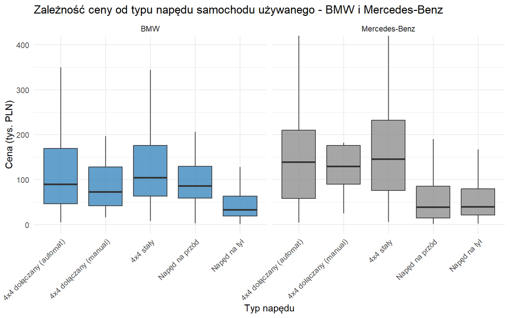

```r
library(ggplot2)
library(dplyr)

# Filtrujemy samochody używane i usuwamy brakujące wartości w Drive
dane_used <- dane %>%
  filter(Condition == "Used" & !(Drive ==""))

ggplot(dane_used, aes(x = Drive, y = Price, fill = Vehicle_brand)) +
  geom_boxplot(outlier.shape = NA, alpha = 0.7) +
  facet_grid(~ Vehicle_brand, scales = "fixed") +
  coord_cartesian(ylim = c(0, 400000)) +
  labs(
    title = "Zależność ceny od typu napędu samochodu używanego - BMW i Mercedes-Benz",
    x = "Typ napędu",
    y = "Cena (tys. PLN)"
  ) +
  scale_y_continuous(
    labels = function(x) x / 1000
  ) +
  scale_x_discrete(labels = c(
    "4x4 (attached automatically)" = "4x4 dołączany (automat)",
    "4x4 (attached manually)"  = "4x4 dołączany (manual)",
    "4x4 (permanent)"          = "4x4 stały",
    "Front wheels"             = "Napęd na przód",
    "Rear wheels"              = "Napęd na tył"
  )) +
  scale_fill_manual(values = brand_colors) +  # używamy palety kolorów marek
  theme_minimal() +
  theme(
    axis.text.x = element_text(angle = 45, hjust = 1),
    legend.position = "none"  # ukrywamy legendę
  )
```

```r
library(dplyr)
library(knitr)
library(kableExtra)
library(scales)

# Przygotowanie danych do tabeli H6
tab_h6 <- dane %>%
  filter(
    Condition == "Used",
    Vehicle_brand %in% c("BMW", "Mercedes-Benz"),
    !is.na(Price),
    Price <= 400000,
    Drive != ""
  ) %>%
  # Możemy przypisać polskie nazwy napędu tak jak na wykresie
  mutate(
    Typ_napedu = case_when(
      Drive == "4x4 (attached automatically)" ~ "4x4 dołączany (automat)",
      Drive == "4x4 (attached manually)" ~ "4x4 dołączany (manual)",
      Drive == "4x4 (permanent)" ~ "4x4 stały",
      Drive == "Front wheels" ~ "Napęd na przód",
      Drive == "Rear wheels" ~ "Napęd na tył",
      TRUE ~ Drive
    )
  ) %>%
  group_by(Vehicle_brand, Typ_napedu) %>%
  summarise(
    n = sum(!is.na(Price)),
    Srednia = mean(Price, na.rm = TRUE),
    Q1 = quantile(Price, 0.25, na.rm = TRUE),
    Mediana = median(Price, na.rm = TRUE),
    Q3 = quantile(Price, 0.75, na.rm = TRUE),
    .groups = "drop"
  ) %>%
  rename(Marka = Vehicle_brand, `Typ napędu` = Typ_napedu) %>%
  arrange(Marka, `Typ napędu`) %>%
  mutate(across(c(n, Srednia, Q1, Mediana, Q3), ~comma(round(.x, 0), big.mark = " ")))

# Render tabeli w stylu raportowym
tab_h6 %>%
  kable(
    "html",
    caption = "H6: Cena samochodu w zależności od typu napędu (używane, Price ≤ 400 000)",
    align = "c",
    col.names = c("Marka", "Typ napędu", "Liczba", "Średnia", "Q1", "Mediana", "Q3")
  ) %>%
  kable_styling(
    full_width = FALSE,
    bootstrap_options = c("striped", "condensed", "hover")
  ) %>%
  row_spec(0, bold = TRUE, color = "white", background = "#2C3E50")
```

H6: Cena samochodu w zależności od typu napędu (używane, Price ≤ 400 000)

| Marka | Typ napędu | Liczba | Średnia | Q1 | Mediana | Q3 |
| --- | --- | --- | --- | --- | --- | --- |
| BMW | 4x4 dołączany (automat) | 2 157 | 110 739 | 45 700 | 86 500 | 159 900 |
| BMW | 4x4 dołączany (manual) | 8 | 80 640 | 37 650 | 71 350 | 103 155 |
| BMW | 4x4 stały | 2 758 | 119 767 | 61 900 | 99 500 | 165 289 |
| BMW | Napęd na przód | 572 | 91 914 | 58 868 | 85 700 | 129 900 |
| BMW | Napęd na tył | 8 473 | 48 448 | 19 000 | 32 900 | 62 900 |
| Mercedes-Benz | 4x4 dołączany (automat) | 571 | 142 613 | 54 950 | 131 500 | 199 000 |
| Mercedes-Benz | 4x4 dołączany (manual) | 15 | 120 774 | 85 000 | 129 900 | 174 950 |
| Mercedes-Benz | 4x4 stały | 2 027 | 149 111 | 69 900 | 135 792 | 202 864 |
| Mercedes-Benz | Napęd na przód | 1 917 | 56 048 | 14 500 | 38 745 | 85 000 |
| Mercedes-Benz | Napęd na tył | 5 109 | 59 822 | 20 900 | 39 900 | 77 900 |

Jednocześnie rozkłady dla napędów na jedną oś nie są identyczne między markami: w BMW „napęd na przód” jest cenowo zbliżony do 4x4 dołączanego (automat) i wyraźnie wyższy niż „napęd na tył”. W Mercedes-Benz sytuacja jest bardziej jednoznaczna: napęd na przód i na tył mają podobne poziomy cen, natomiast 4x4 (stały i dołączany) tworzy wyraźnie droższy segment, co wzmacnia ogólny wniosek o przewadze cenowej 4x4.

Hipoteza H7 (Moc silnika a cena) - tylko dla używanych samochodów, według mocy  
Weryfikacja: model regresji z ceną `Price` jako zmienną zależną i `Power_HP`, `Mileage_km`, `Production_year` jako głównymi zmiennymi objaśniającymi.

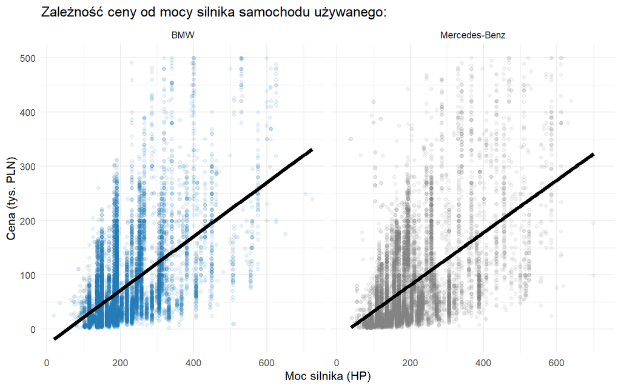

```r
library(ggplot2)
library(dplyr)

# Filtrujemy samochody używane, brakujące wartości i cenę do 500k
dane_used <- dane %>%
  filter(Condition == "Used" & !is.na(Power_HP) & !is.na(Price) & Price <= 500000)

ggplot(dane_used, aes(x = Power_HP, y = Price, color = Vehicle_brand)) +
  geom_point(alpha = 0.1) +
  geom_smooth(aes(group = 1), method = "lm", se = FALSE, color = "black", size = 1.6) +
  facet_grid(~ Vehicle_brand, scales = "fixed") +
  labs(
    title = "Zależność ceny od mocy silnika samochodu używanego:"
  ) +
  scale_x_continuous(name = "Moc silnika (HP)") +
  scale_y_continuous(
    labels = function(x) x / 1000,
    name = "Cena (tys. PLN)"
  ) +
  scale_color_manual(values = brand_colors) +
  theme_minimal() +
  theme(
    legend.position = "none"
  )
```

```r
library(dplyr)
library(knitr)
library(kableExtra)
library(scales)

# Przygotowanie danych
tab_h7 <- dane %>%
  filter(
    Condition == "Used",
    !is.na(Power_HP),
    !is.na(Price),
    Price <= 500000
  ) %>%
  filter(Vehicle_brand %in% c("BMW", "Mercedes-Benz")) %>%
  group_by(Vehicle_brand) %>%
  summarise(
    n = n(),
    Srednia = mean(Price, na.rm = TRUE),
    Q1 = quantile(Price, 0.25, na.rm = TRUE),
    Mediana = median(Price, na.rm = TRUE),
    Q3 = quantile(Price, 0.75, na.rm = TRUE),
    r_cena_moc = cor(Power_HP, Price, use = "complete.obs", method = "pearson"),
    .groups = "drop"
  ) %>%
  rename(Marka = Vehicle_brand) %>%
  mutate(across(c(n, Srednia, Q1, Mediana, Q3), ~comma(round(.x, 0), big.mark = " "))) %>%
  mutate(r_cena_moc = round(r_cena_moc, 2))  # korelacja z dwoma miejscami po przecinku

# Render tabeli w stylu raportowym
tab_h7 %>%
  kable(
    "html",
    caption = "H7: Cena a moc silnika samochodu używanego (używane, Price ≤ 500 000) – korelacja r",
    align = "c",
    col.names = c("Marka", "Liczba", "Średnia", "Q1", "Mediana", "Q3", "Wsp korelacji")
  ) %>%
  kable_styling(
    full_width = FALSE,
    bootstrap_options = c("striped", "condensed", "hover")
  ) %>%
  row_spec(0, bold = TRUE, color = "white", background = "#2C3E50")
```

H7: Cena a moc silnika samochodu używanego (używane, Price ≤ 500 000) – korelacja r

| Marka | Liczba | Średnia | Q1 | Mediana | Q3 | Wsp korelacji |
| --- | --- | --- | --- | --- | --- | --- |
| BMW | 15 068 | 75 308 | 24 470 | 51 000 | 98 000 | 0.55 |
| Mercedes-Benz | 10 796 | 84 160 | 22 000 | 50 999 | 119 000 | 0.55 |

Dane na wykresie i w tabeli wspierają Hipotezę 7: mocniejsze samochody używane są przeciętnie droższe, a zależność ma zbliżoną siłę w BMW i Mercedes-Benz (r ≈ 0.55). Jednocześnie widoczny rozrzut punktów wokół linii trendu pokazuje, że sama moc nie wyjaśnia całej zmienności ceny, ale stanowi ważny czynnik różnicujący oferty.